# Povečanje resolucije MR slik

Predlog za projekt za predmet Osnove strojnega učenja in podatkovnega rudarjenja

Author

Jan Panjan, 89231282

Published

February 19, 2025

# CAUTION: VERJETNO BOM UPORABIL PROSTATE PODATKE, PRILAGODI DOKUMENT!!!

**TLDR**

Povečanje resolucije oziroma *upscaling* MR slik s pomočjo Generative adversarial neural network (GAN).

## Podatki

Podatki so dostopni preko na spletni strani [fastMRI Dataset](https://fastmri.med.nyu.edu/), a je za to potreben dostop s pomočjo email-a. Na voljo je mnogo podatkov (Figure 1). Uporabljal bom podatke o kolenih (*Knee MRI*), ki vsebuje več kot 1500 *fully sampled* MR slik kolen.

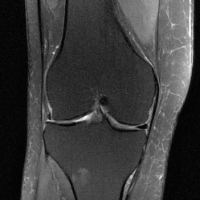

Podatki predstavljajo tako imenovan *k-space*. To so neobdelani podatki pridobljeni z magnetno resonanco. k-prostor je matematični prikaz frekvenc in faz signalov in se v MR slike pretvori s Fourierjevo transformacijo.

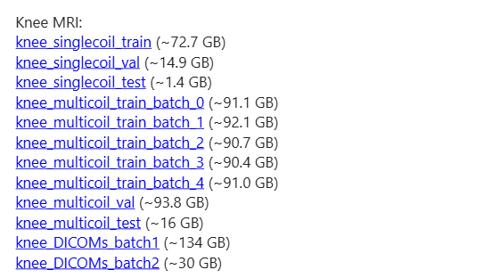

Figure 1: kot je razvidno je podatkov malo morje. Probal se bom omejiti na en komplet podatkov (~90GB).

Shranjeni so v h5 file format in imajo naslednje atribute:

- **ismrmrd_header**: razni metapodatki
- **k-space**: 3-dimenzionalna matrika surovih podatkov k-prostora v obliki kompleksnih števil
- **mask**: maska, ki se uporablja za označevanje določenih delov k-prostora (služi večim namenom) v obliki 1-dimenzionalnega seznama binarnih vrednosti

## Problem

*Fully sampled* podatke je težko pridobiti, saj zahtevajo dolg čas skeniranja. Na kvaliteto vplivajo tudi premikanje pacienta, zmogljivost naprave, itn. Poleg faktorjev med skeniranjem je proces sestavljanja MR slike iz večih slojev tudi podvržen motečim faktorjem, npr. šum v podatkih, t.i. *artifacts*, ipd.

Zaradi tega so ponavadi MR slike slabe kvalitete, kar oteži njihovo analiziranje in potencialno odkrivanje anomalij in dobro diagnozo. V najslabšem primeru je potrebno tudi ponovno skeniranje pacienta.

## Cilj

S pomočjo GAN natrenirati model, ki bo sposoben sprejeti MR sliko nizke resolucije in generirati novo *sintetično* (a dovolj resnično) MR sliko visoke resolucije, ki bo dovolj kvalitetna za dobro nadaljno analizo.

## Metode in knjižnice

V osnovi bom uporabljal bom Python s knjižnico TensorFlow. Ustvaril bom GAN, torej dve nevronski mreži, generator in diskriminator, ki bosta delala eden proti drugemu.

Ker je podatkov zelo veliko, bom poiskusil trenirati model v *batches*, tako da vzamem nek subset, natreniram model, ga shranim in nato ponovno natreniram z novimi podatki.